# R Notebook

Kiante Fernandez

# Main Hypotheses

1. Consistent with previous research on behavioral economics and moral decision making, we hypothesize that participants will be more psychologically risk averse to harm than gain motivated.
2. Participants risk aversion to harm will change as the cognitive domain being treated changes. Specifically, participants will be more risk averse to mood, and self-control because these are more central to self-identity.
3. Participants who are more affluent, educated, liberal, and younger will be risk seeking relative to the average risky decision making behavior observed when judging treatments for others.
- note: we need income, age, education, and political affli here.
4. In a classification model, the proportion of benefit to harm ratio will be more predictive of whether someone chooses an experimental treatment than the benefits or risks alone.

## Set the stage

```r
source("../r_docs/LoadLibraries.R")
LoadLibraries()
```

```
## [1] "Libaries locked and loaded"
```

```r
###Add Survey Data
survey = read.csv("../data/Qualtrics Data/Risk_Data.csv", header=FALSE, comment.char="#", stringsAsFactors=TRUE)
survey = survey[,-c(1:13)]
questions_strings = survey[1,] #Question ID's
survey = survey[-1,]
colnames(survey)[1]= 'user_id'
colnames(survey)[19]= 'Attention_Check'
survey = filter(survey, Attention_Check == 0)

Demographics = survey[, 97:101]
colnames(Demographics) = c('Sex','Age', 'Race/Ethnicity', 'Education', 'Religion')
Demographics = cbind(Demographics, survey[1])
cleanPilot = merge(cleanPilot, Demographics, "user_id")
```

```r
#Check the RT data for outliers
n= 46
trial_index = data_frame(rep.int(c(1:75), n)) #MAKE SURE THIS IS EQUAL TO THE NUMBER OF SUBJECTS after attention check
colnames(trial_index)= c("trial_index")

cleanPilot = cbind(cleanPilot,trial_index)
cleanPilot$trial_index = factor(cleanPilot$trial_index)

cleanPilot = filter(cleanPilot, rt <= 60000 & rt >= 250)

cleanPilot =subset(cleanPilot, with(cleanPilot, user_id %in% names(which(table(user_id)>=N)))) #Remove Subjects who do not have 75 trials

#table(cleanPilot$user_id) Sanity Check
cleanPilot$user_id = factor(cleanPilot$user_id)
RT = select_(cleanPilot,"user_id", "rt", "trial_index")
summary(RT)
```

```
##      user_id           rt           trial_index
##  01rSsifR:  75   Min.   :  305.1   1      :  39
##  19x3QrYn:  75   1st Qu.:  723.0   2      :  39
##  2OsQQK3Z:  75   Median : 1121.4   3      :  39
##  2X1xhDjv:  75   Mean   : 1614.2   4      :  39
##  363Bpm6B:  75   3rd Qu.: 1756.4   5      :  39
##  3eryCPLE:  75   Max.   :36954.0   6      :  39
##  (Other) :2475                     (Other):2691
```

```r
##Plots for RT
data_long = melt(RT,
                 id=c("user_id","trial_index"),
                 measure=c("rt"))

summary(data_long)
```

```
##      user_id      trial_index   variable      value
##  01rSsifR:  75   1      :  39   rt:2925   Min.   :  305.1
##  19x3QrYn:  75   2      :  39             1st Qu.:  723.0
##  2OsQQK3Z:  75   3      :  39             Median : 1121.4
##  2X1xhDjv:  75   4      :  39             Mean   : 1614.2
##  363Bpm6B:  75   5      :  39             3rd Qu.: 1756.4
##  3eryCPLE:  75   6      :  39             Max.   :36954.0
##  (Other) :2475   (Other):2691
```

```
## geom_path: Each group consists of only one observation. Do you need to adjust
## the group aesthetic?
```

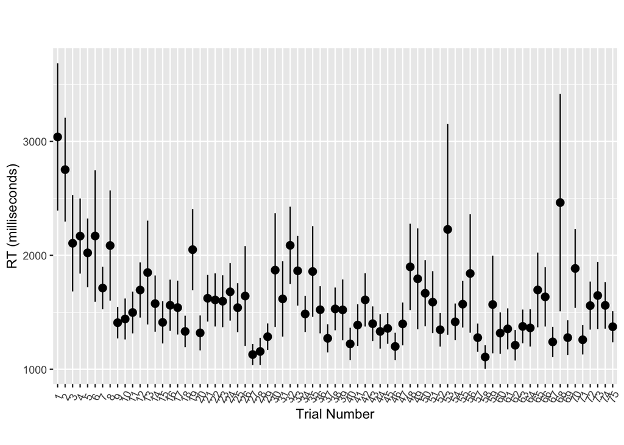

```r
ggplot(data_long, aes(trial_index, value)) +
  stat_summary(fun = mean, geom = "line") +
  stat_summary(fun.data=mean_se, geom = "pointrange") +
  scale_y_continuous("RT (milliseconds)") +
  theme(axis.text.x = element_text(angle=65, vjust=0.6)) +
  labs(title="",
       subtitle="",
       caption="",
       x="Trial Number",
       y="RT (milliseconds)")
```

```r
datalist = list()
for (i in RT$user_id){
  x = filter(RT, user_id == i)
  dat = summary(x$rt)
  datalist[[i]] = dat # add it to your list
}

user_id = factor(names(datalist)) #creates vector of user_id's

for (i in user_id){
  x = filter(RT, user_id == i)
  sum = summary(x)
  print(sum)
  }
```

```
##      user_id         rt          trial_index
##  01rSsifR:75   Min.   : 529.5   1      : 1
##  19x3QrYn: 0   1st Qu.: 738.0   2      : 1
##  2OsQQK3Z: 0   Median : 944.8   3      : 1
##  2X1xhDjv: 0   Mean   :1234.4   4      : 1
##  363Bpm6B: 0   3rd Qu.:1085.3   5      : 1
##  3eryCPLE: 0   Max.   :5776.4   6      : 1
##  (Other) : 0                    (Other):69
##      user_id         rt           trial_index
##  19x3QrYn:75   Min.   :  337.6   1      : 1
##  01rSsifR: 0   1st Qu.:  570.7   2      : 1
##  2OsQQK3Z: 0   Median :  717.7   3      : 1
##  2X1xhDjv: 0   Mean   : 1823.8   4      : 1
##  363Bpm6B: 0   3rd Qu.: 1331.1   5      : 1
##  3eryCPLE: 0   Max.   :17765.3   6      : 1
##  (Other) : 0                     (Other):69
##      user_id         rt          trial_index
##  2OsQQK3Z:75   Min.   : 596.4   1      : 1
##  01rSsifR: 0   1st Qu.:1059.4   2      : 1
##  19x3QrYn: 0   Median :1324.0   3      : 1
##  2X1xhDjv: 0   Mean   :1663.5   4      : 1
##  363Bpm6B: 0   3rd Qu.:1807.9   5      : 1
##  3eryCPLE: 0   Max.   :5763.6   6      : 1
##  (Other) : 0                    (Other):69
##      user_id         rt        trial_index
##  2X1xhDjv:75   Min.   : 843   1      : 1
##  01rSsifR: 0   1st Qu.:1064   2      : 1
##  19x3QrYn: 0   Median :1377   3      : 1
##  2OsQQK3Z: 0   Mean   :1540   4      : 1
##  363Bpm6B: 0   3rd Qu.:1716   5      : 1
##  3eryCPLE: 0   Max.   :4193   6      : 1
##  (Other) : 0                  (Other):69
##      user_id         rt          trial_index
##  363Bpm6B:75   Min.   : 348.2   1      : 1
##  01rSsifR: 0   1st Qu.: 415.8   2      : 1
##  19x3QrYn: 0   Median : 459.7   3      : 1
##  2OsQQK3Z: 0   Mean   : 590.1   4      : 1
##  2X1xhDjv: 0   3rd Qu.: 608.7   5      : 1
##  3eryCPLE: 0   Max.   :4294.4   6      : 1
##  (Other) : 0                    (Other):69
```

[output cut: 257 more lines]

```
##  zeRcEHIn:75   Min.   :  953.8   1      : 1
##  01rSsifR: 0   1st Qu.: 1444.3   2      : 1
##  19x3QrYn: 0   Median : 1797.0   3      : 1
##  2OsQQK3Z: 0   Mean   : 2955.4   4      : 1
##  2X1xhDjv: 0   3rd Qu.: 2874.5   5      : 1
##  363Bpm6B: 0   Max.   :22982.9   6      : 1
##  (Other) : 0                     (Other):69
##      user_id         rt          trial_index
##  zrwNx8or:75   Min.   : 696.2   1      : 1
##  01rSsifR: 0   1st Qu.:1229.2   2      : 1
##  19x3QrYn: 0   Median :1544.4   3      : 1
##  2OsQQK3Z: 0   Mean   :2057.4   4      : 1
##  2X1xhDjv: 0   3rd Qu.:2501.9   5      : 1
##  363Bpm6B: 0   Max.   :5703.0   6      : 1
##  (Other) : 0                    (Other):69
```

```r
rm(data_long, x, datalist, trial_index)
```

```r
#cleanPilot = merge(cleanPilot, survey, "user_id")
#cleanPilot = merge(cleanPilot, Demographics, "user_id")

Neuroethics_Judgement = cleanPilot
Neuroethics_Judgement$experimental_treatment_selected = factor(Neuroethics_Judgement$experimental_treatment_selected, labels = c("No to treatment","Yes to treatment"))

#user_id = as.character(distinct(Neuroethics_Judgement,user_id))
```

```r
#How many observatoins does each subject have in each class (yes and no)?
datalist = list()
for (i in Neuroethics_Judgement$user_id){
  x = filter(Neuroethics_Judgement, user_id == i)
  dat = table(x$experimental_treatment_selected) #Check Class bias
  datalist[[i]] = dat # add it to your list
}
Observation_Counts = do.call(rbind, datalist)
colnames(Observation_Counts) = c('No', 'Yes')
summary(Observation_Counts)
```

```
##        No             Yes
##  Min.   : 0.00   Min.   : 2.00
##  1st Qu.:35.00   1st Qu.:15.50
##  Median :50.00   Median :25.00
##  Mean   :45.38   Mean   :29.62
##  3rd Qu.:59.50   3rd Qu.:40.00
##  Max.   :73.00   Max.   :75.00
```

```r
View(Observation_Counts)
rm(i, x,datalist, dat)
```

## H1

Consistent with previous research on behavioral economics and moral decision making, we hypothesize that participants will be more psychologically risk averse to harm than gain motivated.

To do so, we will fit a binary logistic regression on the task data to display the subject wise sensitivity to risk of harm above and beyond that gain motivated judgments.

The outcome (response) variable is binary (0/1); No treatment or Yes to experimental treatment. The predictor variables of interest are the amount of risk, gain, and no_effect within each trial.

```r
####Logsistic Reg

subjectModel.1 = by(Neuroethics_Judgement, Neuroethics_Judgement$user_id, function(x) glm(experimental_treatment_selected ~ risk, data = x, family = binomial(link = "logit"),control=glm.control(maxit=50)))

subjectModel.2 = by(Neuroethics_Judgement, Neuroethics_Judgement$user_id, function(x) glm(experimental_treatment_selected ~ risk + gain, data = x, family = binomial(link = "logit"),control=glm.control(maxit=50)))

subjectModel.3 = by(Neuroethics_Judgement, Neuroethics_Judgement$user_id, function(x) glm(experimental_treatment_selected ~ risk + gain + risk*gain, data = x, family = binomial(link = "logit"),control=glm.control(maxit=50)))
```

```r
user_id = names(subjectModel.1) #creates vector of user_id's

#loop an anove test of the interaction on base and ratio model
datalist = list()
for (i in 1:39){
dat = anova(subjectModel.1[[i]],
            subjectModel.2[[i]],
            subjectModel.3[[i]],
            test="Chisq")
  datalist[[i]] = dat
}
names(datalist) = user_id

lapply(datalist, print)
```

```
## Analysis of Deviance Table
##
## Model 1: experimental_treatment_selected ~ risk
## Model 2: experimental_treatment_selected ~ risk + gain
## Model 3: experimental_treatment_selected ~ risk + gain + risk * gain
##   Resid. Df Resid. Dev Df Deviance  Pr(>Chi)
## 1        73     47.976
## 2        72     15.539  1   32.437 1.231e-08 ***
## 3        71     12.909  1    2.629    0.1049
## ---
## Signif. codes:  0 '***' 0.001 '**' 0.01 '*' 0.05 '.' 0.1 ' ' 1
## Analysis of Deviance Table
##
## Model 1: experimental_treatment_selected ~ risk
## Model 2: experimental_treatment_selected ~ risk + gain
## Model 3: experimental_treatment_selected ~ risk + gain + risk * gain
##   Resid. Df Resid. Dev Df Deviance  Pr(>Chi)
## 1        73     50.515
## 2        72     49.332  1   1.1833 0.2766778
## 3        71     36.683  1  12.6488 0.0003758 ***
## ---
## Signif. codes:  0 '***' 0.001 '**' 0.01 '*' 0.05 '.' 0.1 ' ' 1
## Analysis of Deviance Table
##
## Model 1: experimental_treatment_selected ~ risk
## Model 2: experimental_treatment_selected ~ risk + gain
## Model 3: experimental_treatment_selected ~ risk + gain + risk * gain
##   Resid. Df Resid. Dev Df Deviance  Pr(>Chi)
## 1        73     89.143
## 2        72     64.335  1   24.808 6.332e-07 ***
## 3        71     51.247  1   13.088 0.0002972 ***
## ---
## Signif. codes:  0 '***' 0.001 '**' 0.01 '*' 0.05 '.' 0.1 ' ' 1
## Analysis of Deviance Table
##
## Model 1: experimental_treatment_selected ~ risk
## Model 2: experimental_treatment_selected ~ risk + gain
## Model 3: experimental_treatment_selected ~ risk + gain + risk * gain
##   Resid. Df Resid. Dev Df Deviance  Pr(>Chi)
## 1        73    27.7901
```

[output cut: 354 more lines]

```
## 2        72     22.374  1   5.9833  0.01444 *
## 3        71     21.009  1   1.3648  0.24270
## ---
## Signif. codes:  0 '***' 0.001 '**' 0.01 '*' 0.05 '.' 0.1 ' ' 1
## Analysis of Deviance Table
##
## Model 1: experimental_treatment_selected ~ risk
## Model 2: experimental_treatment_selected ~ risk + gain
## Model 3: experimental_treatment_selected ~ risk + gain + risk * gain
##   Resid. Df Resid. Dev Df Deviance  Pr(>Chi)
## 1        73     37.339
## 2        72     14.803  1  22.5356 2.063e-06 ***
## 3        71      9.344  1   5.4587   0.01947 *
## ---
## Signif. codes:  0 '***' 0.001 '**' 0.01 '*' 0.05 '.' 0.1 ' ' 1
```

```
## $`01rSsifR`
## Analysis of Deviance Table
##
## Model 1: experimental_treatment_selected ~ risk
## Model 2: experimental_treatment_selected ~ risk + gain
## Model 3: experimental_treatment_selected ~ risk + gain + risk * gain
##   Resid. Df Resid. Dev Df Deviance  Pr(>Chi)
## 1        73     47.976
## 2        72     15.539  1   32.437 1.231e-08 ***
## 3        71     12.909  1    2.629    0.1049
## ---
## Signif. codes:  0 '***' 0.001 '**' 0.01 '*' 0.05 '.' 0.1 ' ' 1
##
## $`19x3QrYn`
## Analysis of Deviance Table
##
## Model 1: experimental_treatment_selected ~ risk
## Model 2: experimental_treatment_selected ~ risk + gain
## Model 3: experimental_treatment_selected ~ risk + gain + risk * gain
##   Resid. Df Resid. Dev Df Deviance  Pr(>Chi)
## 1        73     50.515
## 2        72     49.332  1   1.1833 0.2766778
## 3        71     36.683  1  12.6488 0.0003758 ***
## ---
## Signif. codes:  0 '***' 0.001 '**' 0.01 '*' 0.05 '.' 0.1 ' ' 1
##
## $`2OsQQK3Z`
## Analysis of Deviance Table
##
## Model 1: experimental_treatment_selected ~ risk
## Model 2: experimental_treatment_selected ~ risk + gain
## Model 3: experimental_treatment_selected ~ risk + gain + risk * gain
##   Resid. Df Resid. Dev Df Deviance  Pr(>Chi)
## 1        73     89.143
## 2        72     64.335  1   24.808 6.332e-07 ***
## 3        71     51.247  1   13.088 0.0002972 ***
## ---
## Signif. codes:  0 '***' 0.001 '**' 0.01 '*' 0.05 '.' 0.1 ' ' 1
##
## $`2X1xhDjv`
```

[output cut: 431 more lines]

```
## ---
## Signif. codes:  0 '***' 0.001 '**' 0.01 '*' 0.05 '.' 0.1 ' ' 1
##
## $zrwNx8or
## Analysis of Deviance Table
##
## Model 1: experimental_treatment_selected ~ risk
## Model 2: experimental_treatment_selected ~ risk + gain
## Model 3: experimental_treatment_selected ~ risk + gain + risk * gain
##   Resid. Df Resid. Dev Df Deviance  Pr(>Chi)
## 1        73     37.339
## 2        72     14.803  1  22.5356 2.063e-06 ***
## 3        71      9.344  1   5.4587   0.01947 *
## ---
## Signif. codes:  0 '***' 0.001 '**' 0.01 '*' 0.05 '.' 0.1 ' ' 1
```

```r
source("../r_docs/logisticPseudoR2s.R")

#loop the r^2 calculator on the fitted final model
datalist.1 = list()
for (i in 1:39){
dat = logisticPseudoR2s(subjectModel.2[[i]])
  datalist.1[[i]] = dat
}
```

```
## Pseudo R^2 for logistic regression
## Hosmer and Lemeshow R^2   0.829
## Cox and Snell R^2         0.633
## Nagelkerke R^2            0.902
## Pseudo R^2 for logistic regression
## Hosmer and Lemeshow R^2   0.162
## Cox and Snell R^2         0.12
## Nagelkerke R^2            0.22
## Pseudo R^2 for logistic regression
## Hosmer and Lemeshow R^2   0.379
## Cox and Snell R^2         0.408
## Nagelkerke R^2            0.545
## Pseudo R^2 for logistic regression
## Hosmer and Lemeshow R^2   0.859
## Cox and Snell R^2         0.631
## Nagelkerke R^2            0.919
## Pseudo R^2 for logistic regression
## Hosmer and Lemeshow R^2   0.579
## Cox and Snell R^2         0.427
## Nagelkerke R^2            0.691
## Pseudo R^2 for logistic regression
## Hosmer and Lemeshow R^2   0.539
## Cox and Snell R^2         0.378
## Nagelkerke R^2            0.646
## Pseudo R^2 for logistic regression
## Hosmer and Lemeshow R^2   0.492
## Cox and Snell R^2         0.482
## Nagelkerke R^2            0.654
## Pseudo R^2 for logistic regression
## Hosmer and Lemeshow R^2   0.701
## Cox and Snell R^2         0.491
## Nagelkerke R^2            0.794
## Pseudo R^2 for logistic regression
## Hosmer and Lemeshow R^2   0.027
## Cox and Snell R^2         0.034
## Nagelkerke R^2            0.047
## Pseudo R^2 for logistic regression
## Hosmer and Lemeshow R^2   0.782
## Cox and Snell R^2         0.578
## Nagelkerke R^2            0.865
```

[output cut: 101 more lines]

```
## Hosmer and Lemeshow R^2   0.386
## Cox and Snell R^2         0.405
## Nagelkerke R^2            0.548
## Pseudo R^2 for logistic regression
## Hosmer and Lemeshow R^2   0.353
## Cox and Snell R^2         0.083
## Nagelkerke R^2            0.381
## Pseudo R^2 for logistic regression
## Hosmer and Lemeshow R^2   0.785
## Cox and Snell R^2         0.663
## Nagelkerke R^2            0.884
## Pseudo R^2 for logistic regression
## Hosmer and Lemeshow R^2   0.851
## Cox and Snell R^2         0.675
## Nagelkerke R^2            0.921
```

```r
#subjectModel.R2 <-  do.call(rbind, datalist.1)
```

```r
#Compute odds ratio
datalist.2 = list()
for (i in 1:39){
dat = exp(subjectModel.2[[i]]$coefficients)
  datalist.2[[i]] = dat
}
subjectModel.OddRatios = do.call(rbind, datalist.2)
colnames(subjectModel.OddRatios)= c('Intercept', 'Risk_Beta', 'Gain_Beta')
subjectModel.OddRatios = cbind(subjectModel.OddRatios, user_id)

#Coefficients Extraction

Neuroethics_Judgement= merge(Neuroethics_Judgement, subjectModel.OddRatios, "user_id")
```

```r
#Diagnostics for model 2 (Residuals)

#Interpreting residuaLs

datalist.dignostics = list()
for (i in user_id){
subjectDignostics = filter(Neuroethics_Judgement, user_id == i)
  for (ii in 1:39){
    subjectDignostics$predicted.probabilities<-fitted(subjectModel.2[[ii]])
    subjectDignostics$standardized.residuals<-rstandard(subjectModel.2[[ii]])
    subjectDignostics$studentized.residuals<-rstudent(subjectModel.2[[ii]])
    subjectDignostics$dfbeta<-dfbeta(subjectModel.2[[ii]])
    subjectDignostics$dffit<-dffits(subjectModel.2[[ii]])
    subjectDignostics$leverage<-hatvalues(subjectModel.2[[ii]])
  }
    datalist.dignostics[[i]] = subjectDignostics
}

datalist.dignostics = do.call(rbind, datalist.dignostics)


#expected leverage is (k + 1)/N
 explev = 3/75
#Neuroethics_Judgement = merge(Neuroethics_Judgement,datalist.dignostics, "user_id")
summary(datalist.dignostics)
```

```
##      user_id                           condition    total_trials
##  01rSsifR:  75   Attention (Concentration)  :450   Min.   :75
##  19x3QrYn:  75   Language (spoken)          :300   1st Qu.:75
##  2OsQQK3Z:  75   Long Term Memory           :225   Median :75
##  2X1xhDjv:  75   Mood                       :600   Mean   :75
##  363Bpm6B:  75   Motor Function             :300   3rd Qu.:75
##  3eryCPLE:  75   Self-control               :150   Max.   :75
##  (Other) :2475   Short Term (Working) Memory:900
##       risk            gain         no_effect
##  Min.   : 5.00   Min.   : 5.00   Min.   : 5.00
##  1st Qu.:25.00   1st Qu.:10.00   1st Qu.:10.00
##  Median :50.00   Median :20.00   Median :20.00
##  Mean   :47.65   Mean   :26.46   Mean   :25.88
##  3rd Qu.:70.00   3rd Qu.:40.00   3rd Qu.:40.00
##  Max.   :90.00   Max.   :90.00   Max.   :90.00
##
##  experimental_treatment_selected   key_press           rt
##  No to treatment :1770           Min.   :77.00   Min.   :  305.1
##  Yes to treatment:1155           1st Qu.:77.00   1st Qu.:  723.0
##                                  Median :77.00   Median : 1121.4
##                                  Mean   :83.39   Mean   : 1614.2
##                                  3rd Qu.:90.00   3rd Qu.: 1756.4
##                                  Max.   :90.00   Max.   :36954.0
##
##      ratio                                              Sex
##  Min.   : 0.05556   Female                                :1650
##  1st Qu.: 0.15385   Male                                  :1275
##  Median : 0.45454   What gender do you most identify with?:   0
##  Mean   : 1.47091
##  3rd Qu.: 1.37500
##  Max.   :18.00000
##
##       Age                                        Race/Ethnicity
##  25     : 300   Asian                                   : 600
##  32     : 300   Black                                   : 150
##  28     : 225   Hispanic or Latino                      : 225
##  29     : 225   Other                                   :  75
##  39     : 225   Which race/ethnicity best describes you?:   0
##  33     : 150   White                                   :1875
##  (Other):1500
```

[output cut: 33 more lines]

```
##  Min.   :-3.170826      Min.   :-0.02564199    Min.   :-0.06062329
##  1st Qu.: 0.000000      1st Qu.:-0.00175766    1st Qu.: 0.00000486
##  Median : 0.000251      Median :-0.00005559    Median : 0.00007741
##  Mean   : 0.017857      Mean   :-0.00044961    Mean   : 0.00004053
##  3rd Qu.: 0.004881      3rd Qu.:-0.00000334    3rd Qu.: 0.00286552
##  Max.   : 1.573696      Max.   : 0.06145623    Max.   : 0.01595642
##
##      dffit              leverage
##  Min.   :-4.317923   Min.   :0.0000000
##  1st Qu.:-0.002002   1st Qu.:0.0003358
##  Median : 0.000014   Median :0.0039670
##  Mean   :-0.040504   Mean   :0.0400000
##  3rd Qu.: 0.010277   3rd Qu.:0.0596689
##  Max.   : 2.095540   Max.   :0.3703011
##
```

```r
#confusionMatrix(ifelse(fitted(subjectModel.2) > .5, "No", "Yes"), d$type)$table
```

## H2

Participants risk aversion to harm will change as the cognitive domain being treated changes. Specifically, participants will be more risk averse to mood, and self-control because these are more central to self-identity.